# MPDW Tugas Praktikum 2

# Library

```r
library("forecast")
library("graphics")
library("tseries")
library("ggplot2")
library("dplyr")
library("TTR")
library("tidyverse")
library("rio")
```

# Data

Dataset yang digunakan berisi **deret waktu harian** pendapatan (*revenue USD*) Google Financial Daily Market selama **15 Juni 2024 s.d. 31 Desember 2024**. Total observasi sekitar **200 titik** yang tersusun berurutan menurut tanggal sehingga cocok dimodelkan sebagai time series.

```r
dt <- import("C:/Users/MUTIARA ARDIANA/OneDrive/Desktop/SEMESTER 5/[3] MPDW/Data Mutiara_Google Financial.xlsx")
```

```r
View(dt)
str(dt)
```

```
## 'data.frame':    200 obs. of  2 variables:
##  $ Date   : POSIXct, format: "2024-06-15" "2024-06-16" ...
##  $ Revenue: num  154 156 155 155 155 ...
```

```r
dim(dt)
```

```
## [1] 200   2
```

```r
n_train <- 160

dt <- dt %>%
    arrange(Date) %>%
  mutate(Set = if_else(row_number() <= n_train, "Train", "Test"),
         Set = factor(Set, levels = c("Train","Test")))

glimpse(dt)
```

```
## Rows: 200
## Columns: 3
## $ Date    <dttm> 2024-06-15, 2024-06-16, 2024-06-17, 2024-06-18, 2024-06-19, 2…
## $ Revenue <dbl> 153.76, 155.88, 155.05, 155.18, 154.95, 154.18, 154.84, 154.45…
## $ Set     <fct> Train, Train, Train, Train, Train, Train, Train, Train, Train,…
```

```r
summary(dt$Revenue)
```

```
##    Min. 1st Qu.  Median    Mean 3rd Qu.    Max.
##   153.5   154.5   154.8   154.8   155.1   156.0
```

```r
sum(is.na(dt$Revenue))
```

```
## [1] 0
```

# Eksplorasi Data

## Split Data

```r
n <- nrow(dt)
n_train <- 160
h <- n - n_train
```

## Plot Data

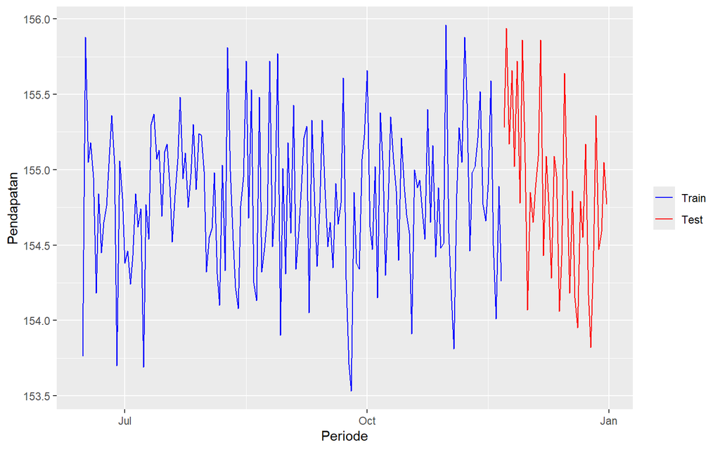

```r
ggplot(dt, aes(Date, Revenue, color = Set)) +
  geom_line() +
  scale_color_manual(values=c("Train"="blue","Test"="red")) +
  labs(x="Periode", y="Pendapatan", color = NULL)
```

## Eksplorasi Data

### Frekuensi mingguan m = 7

```r
y <- ts(dt$Revenue, frequency = 7)
y_train <- window(y, end = c(1, n_train))
y_test  <- window(y, start = c(1, n_train+1))
length(y_train); length(y_test)
```

```
## [1] 160
```

```
## [1] 40
```

### ACF/PCAF, Dekomposisi

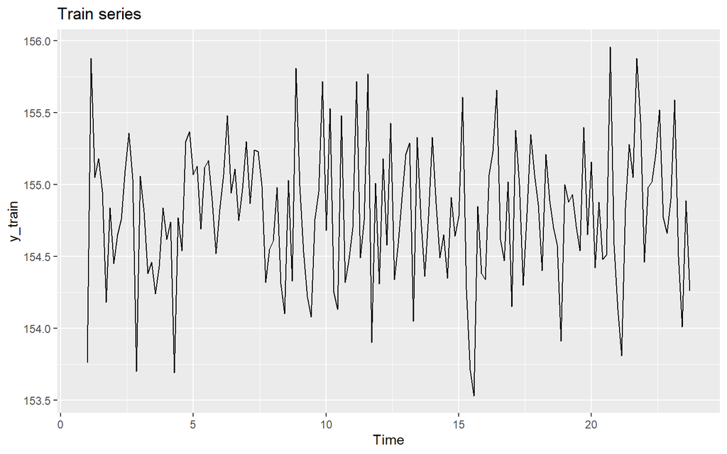

```r
autoplot(y_train) + labs(title="Train series")
```

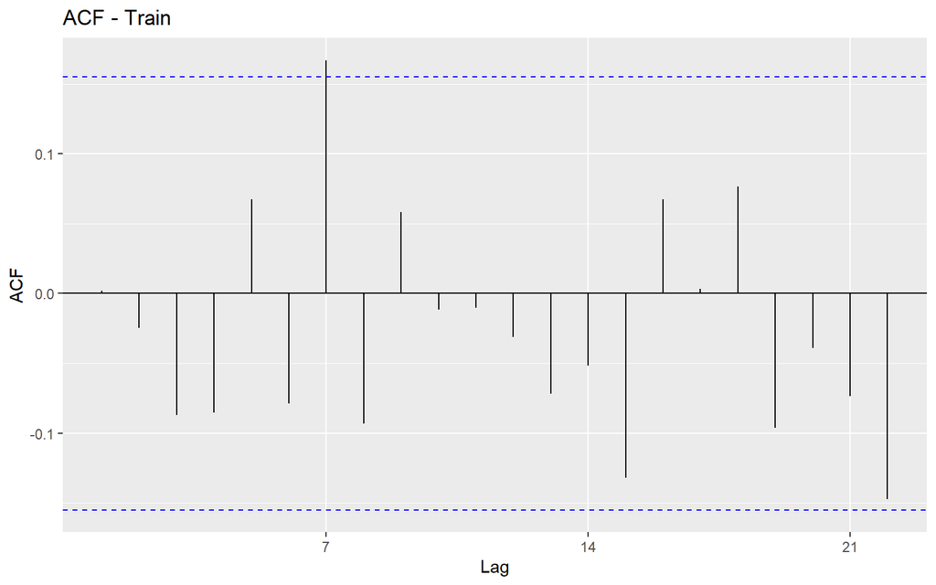

```r
ggAcf(y_train) + labs(title="ACF - Train")
```

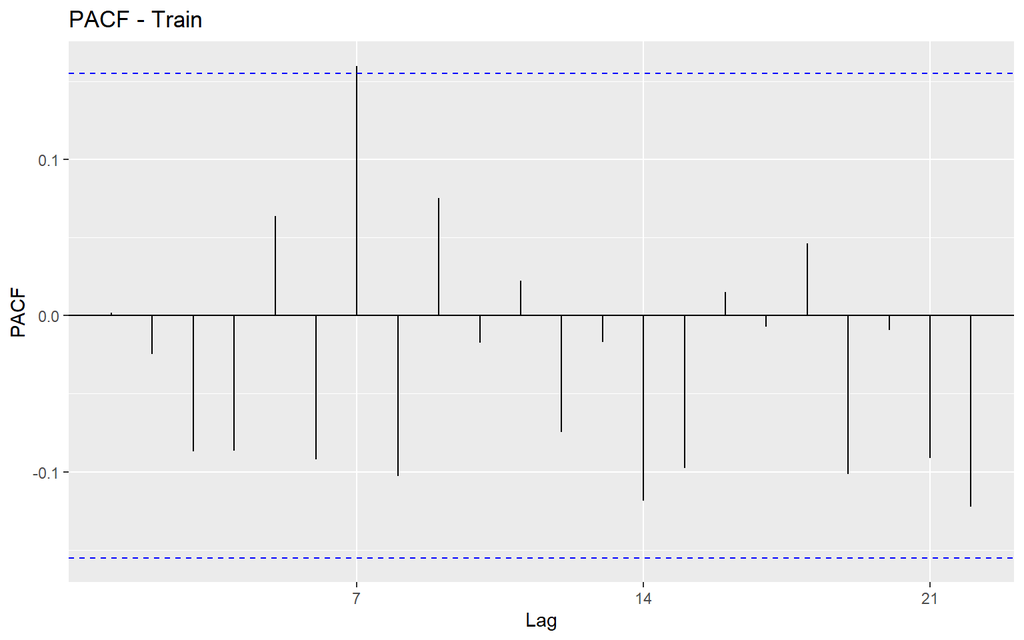

```r
ggPacf(y_train) + labs(title="PACF - Train")
```

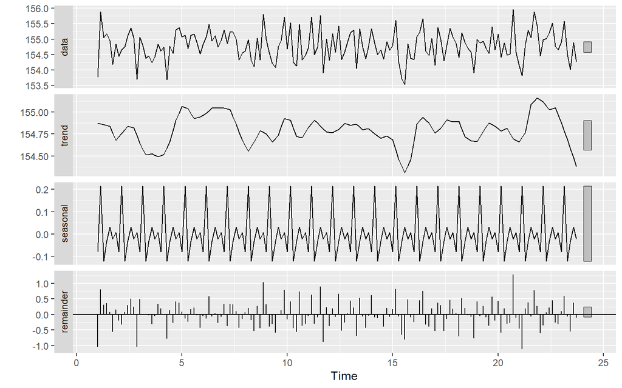

```r
# Dekomposisi STL untuk cek musiman mingguan (m=7)
fit_stl <- stl(y_train, s.window = "periodic")
autoplot(fit_stl)
```

# METODE ANALISIS

```r
library(forecast)
h <- length(y_test)
h
```

```
## [1] 40
```

## Fit Model Kandidat

Berikut adalah model yang dibandingkan dari data latih. Semua model kemudian diramal ke horizon data uji dan dievaluasi dengan MAPE, RMSE, dan sebagainya.

```r
# Benchmark
fit_naive  <- naive(y_train,  h = h)
fit_snaive <- snaive(y_train, h = h)        # musiman mingguan (m=7)

# ETS tanpa musiman (SES)
fit_ets_ann <- ets(y_train, model = "ANN")

# ETS musiman aditif (sesuai pola STL)
fit_ets_ana <- ets(y_train, model = "ANA")

# ARIMA musiman (otomatis)
fit_arima <- auto.arima(
  y_train, seasonal = TRUE, stepwise = FALSE, approximation = FALSE
)
fit_naive; fit_snaive; fit_ets_ann; fit_ets_ana; fit_arima
```

```
##          Point Forecast    Lo 80    Hi 80    Lo 95    Hi 95
## 23.85714         154.26 153.3864 155.1336 152.9240 155.5960
## 24.00000         154.26 153.0246 155.4954 152.3706 156.1494
## 24.14286         154.26 152.7469 155.7731 151.9460 156.5740
## 24.28571         154.26 152.5129 156.0071 151.5880 156.9320
## 24.42857         154.26 152.3066 156.2134 151.2726 157.2474
## 24.57143         154.26 152.1202 156.3998 150.9875 157.5325
## 24.71429         154.26 151.9488 156.5712 150.7253 157.7947
## 24.85714         154.26 151.7892 156.7308 150.4812 158.0388
## 25.00000         154.26 151.6393 156.8807 150.2520 158.2680
## 25.14286         154.26 151.4975 157.0225 150.0352 158.4848
## 25.28571         154.26 151.3627 157.1573 149.8290 158.6910
## 25.42857         154.26 151.2339 157.2861 149.6319 158.8881
## 25.57143         154.26 151.1103 157.4097 149.4430 159.0770
## 25.71429         154.26 150.9914 157.5286 149.2611 159.2589
## 25.85714         154.26 150.8767 157.6433 149.0857 159.4343
## 26.00000         154.26 150.7657 157.7543 148.9160 159.6040
## 26.14286         154.26 150.6582 157.8618 148.7515 159.7685
## 26.28571         154.26 150.5538 157.9662 148.5918 159.9282
## 26.42857         154.26 150.4522 158.0678 148.4365 160.0835
## 26.57143         154.26 150.3533 158.1667 148.2852 160.2348
## 26.71429         154.26 150.2568 158.2632 148.1376 160.3824
## 26.85714         154.26 150.1626 158.3574 147.9936 160.5264
## 27.00000         154.26 150.0705 158.4495 147.8527 160.6673
## 27.14286         154.26 149.9804 158.5396 147.7149 160.8051
## 27.28571         154.26 149.8922 158.6278 147.5800 160.9400
## 27.42857         154.26 149.8057 158.7143 147.4477 161.0723
## 27.57143         154.26 149.7208 158.7992 147.3179 161.2021
## 27.71429         154.26 149.6375 158.8825 147.1905 161.3295
## 27.85714         154.26 149.5557 158.9643 147.0654 161.4546
## 28.00000         154.26 149.4753 159.0447 146.9424 161.5776
## 28.14286         154.26 149.3962 159.1238 146.8214 161.6986
## 28.28571         154.26 149.3183 159.2017 146.7024 161.8176
## 28.42857         154.26 149.2417 159.2783 146.5852 161.9348
## 28.57143         154.26 149.1663 159.3537 146.4698 162.0502
## 28.71429         154.26 149.0919 159.4281 146.3561 162.1639
## 28.85714         154.26 149.0186 159.5014 146.2439 162.2761
## 29.00000         154.26 148.9463 159.5737 146.1334 162.3866
## 29.14286         154.26 148.8750 159.6450 146.0243 162.4957
## 29.28571         154.26 148.8046 159.7154 145.9166 162.6034
## 29.42857         154.26 148.7351 159.7849 145.8103 162.7097
```

```
##          Point Forecast    Lo 80    Hi 80    Lo 95    Hi 95
## 23.85714         154.66 153.8691 155.4509 153.4505 155.8695
## 24.00000         154.90 154.1091 155.6909 153.6905 156.1095
## 24.14286         155.59 154.7991 156.3809 154.3805 156.7995
## 24.28571         154.50 153.7091 155.2909 153.2905 155.7095
## 24.42857         154.01 153.2191 154.8009 152.8005 155.2195
## 24.57143         154.89 154.0991 155.6809 153.6805 156.0995
## 24.71429         154.26 153.4691 155.0509 153.0505 155.4695
## 24.85714         154.66 153.5415 155.7785 152.9494 156.3706
## 25.00000         154.90 153.7815 156.0185 153.1894 156.6106
## 25.14286         155.59 154.4715 156.7085 153.8794 157.3006
## 25.28571         154.50 153.3815 155.6185 152.7894 156.2106
## 25.42857         154.01 152.8915 155.1285 152.2994 155.7206
## 25.57143         154.89 153.7715 156.0085 153.1794 156.6006
## 25.71429         154.26 153.1415 155.3785 152.5494 155.9706
## 25.85714         154.66 153.2902 156.0298 152.5650 156.7550
## 26.00000         154.90 153.5302 156.2698 152.8050 156.9950
## 26.14286         155.59 154.2202 156.9598 153.4950 157.6850
## 26.28571         154.50 153.1302 155.8698 152.4050 156.5950
## 26.42857         154.01 152.6402 155.3798 151.9150 156.1050
## 26.57143         154.89 153.5202 156.2598 152.7950 156.9850
## 26.71429         154.26 152.8902 155.6298 152.1650 156.3550
## 26.85714         154.66 153.0782 156.2418 152.2409 157.0791
## 27.00000         154.90 153.3182 156.4818 152.4809 157.3191
## 27.14286         155.59 154.0082 157.1718 153.1709 158.0091
## 27.28571         154.50 152.9182 156.0818 152.0809 156.9191
## 27.42857         154.01 152.4282 155.5918 151.5909 156.4291
## 27.57143         154.89 153.3082 156.4718 152.4709 157.3091
## 27.71429         154.26 152.6782 155.8418 151.8409 156.6791
## 27.85714         154.66 152.8915 156.4285 151.9554 157.3646
## 28.00000         154.90 153.1315 156.6685 152.1954 157.6046
## 28.14286         155.59 153.8215 157.3585 152.8854 158.2946
## 28.28571         154.50 152.7315 156.2685 151.7954 157.2046
## 28.42857         154.01 152.2415 155.7785 151.3054 156.7146
## 28.57143         154.89 153.1215 156.6585 152.1854 157.5946
## 28.71429         154.26 152.4915 156.0285 151.5554 156.9646
## 28.85714         154.66 152.7227 156.5973 151.6972 157.6228
## 29.00000         154.90 152.9627 156.8373 151.9372 157.8628
## 29.14286         155.59 153.6527 157.5273 152.6272 158.5528
## 29.28571         154.50 152.5627 156.4373 151.5372 157.4628
## 29.42857         154.01 152.0727 155.9473 151.0472 156.9728
```

```
## ETS(A,N,N)
##
## Call:
## ets(y = y_train, model = "ANN")
##
##   Smoothing parameters:
##     alpha = 1e-04
##
##   Initial states:
##     l = 154.7989
##
##   sigma:  0.4885
##
##      AIC     AICc      BIC
## 586.7344 586.8883 595.9600
```

```
## ETS(A,N,A)
##
## Call:
## ets(y = y_train, model = "ANA")
##
##   Smoothing parameters:
##     alpha = 1e-04
##     gamma = 0.0017
##
##   Initial states:
##     l = 154.7861
##     s = -0.0234 -2e-04 -0.0713 0.0096 -0.0683 0.2281
##            -0.0744
##
##   sigma:  0.4918
##
##      AIC     AICc      BIC
## 595.6932 597.1697 626.4450
```

```
## Series: y_train
## ARIMA(0,0,0)(0,0,1)[7] with non-zero mean
##
## Coefficients:
##         sma1      mean
##       0.2033  154.7978
## s.e.  0.0826    0.0450
##
## sigma^2 = 0.2299:  log likelihood = -108.58
## AIC=223.15   AICc=223.31   BIC=232.38
```

## Forecast & Evaluasi Akurasi

Adapun hasil ramalan dan evaluasi akurasi setiap model adalah sebagai berikut.

```r
fc_naive    <- fit_naive
fc_snaive   <- fit_snaive
fc_ets_ann  <- forecast(fit_ets_ann, h = h)
fc_ets_ana  <- forecast(fit_ets_ana, h = h)
fc_arima    <- forecast(fit_arima,   h = h)

tab_acc <- dplyr::bind_rows(
  tibble::as_tibble(accuracy(fc_naive,   y_test)) %>% dplyr::mutate(model="Naive"),
  tibble::as_tibble(accuracy(fc_snaive,  y_test)) %>% dplyr::mutate(model="S-Naive (m=7)"),
  tibble::as_tibble(accuracy(fc_ets_ann, y_test)) %>% dplyr::mutate(model="ETS(ANN) / SES"),
  tibble::as_tibble(accuracy(fc_ets_ana, y_test)) %>% dplyr::mutate(model="ETS(A,N,A)"),
  tibble::as_tibble(accuracy(fc_arima,   y_test)) %>% dplyr::mutate(model="ARIMA musiman")
) %>% dplyr::select(model, ME, RMSE, MAE, MAPE, MASE, ACF1)

tab_acc %>% dplyr::arrange(MAPE)
```

```
## # A tibble: 10 × 7
##    model                  ME  RMSE   MAE  MAPE  MASE     ACF1
##    <chr>               <dbl> <dbl> <dbl> <dbl> <dbl>    <dbl>
##  1 ETS(A,N,A)      0.0125    0.478 0.382 0.247 0.770  0.0257
##  2 ARIMA musiman  -0.000352  0.477 0.385 0.249 0.776  0.0342
##  3 ETS(ANN) / SES  0.0000354 0.485 0.387 0.250 0.780  0.00184
##  4 ETS(ANN) / SES  0.0459    0.548 0.435 0.281 0.878  0.162
##  5 ARIMA musiman   0.0528    0.551 0.440 0.284 0.888  0.184
##  6 ETS(A,N,A)      0.0563    0.564 0.454 0.293 0.915  0.0945
##  7 S-Naive (m=7)  -0.00673   0.617 0.496 0.320 1      0.129
##  8 Naive           0.00314   0.682 0.546 0.353 1.10  -0.461
##  9 S-Naive (m=7)   0.152     0.691 0.577 0.372 1.16   0.0995
## 10 Naive           0.585     0.800 0.656 0.423 1.32   0.162
```

# Model Terbaik Sementara

## Diagnostik Residu (model sementara)

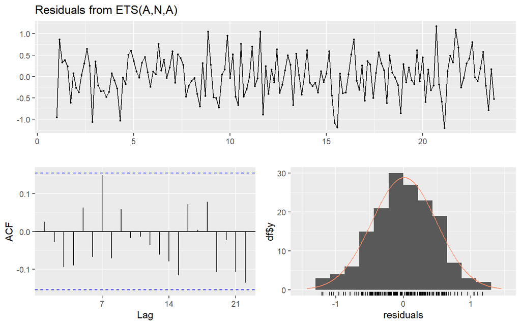

```
##
##  Ljung-Box test
##
## data:  Residuals from ETS(A,N,A)
## Q* = 11.867, df = 14, p-value = 0.617
##
## Model df: 0.   Total lags used: 14
```

```r
# ETS musiman aditif
checkresiduals(fit_ets_ana)
```

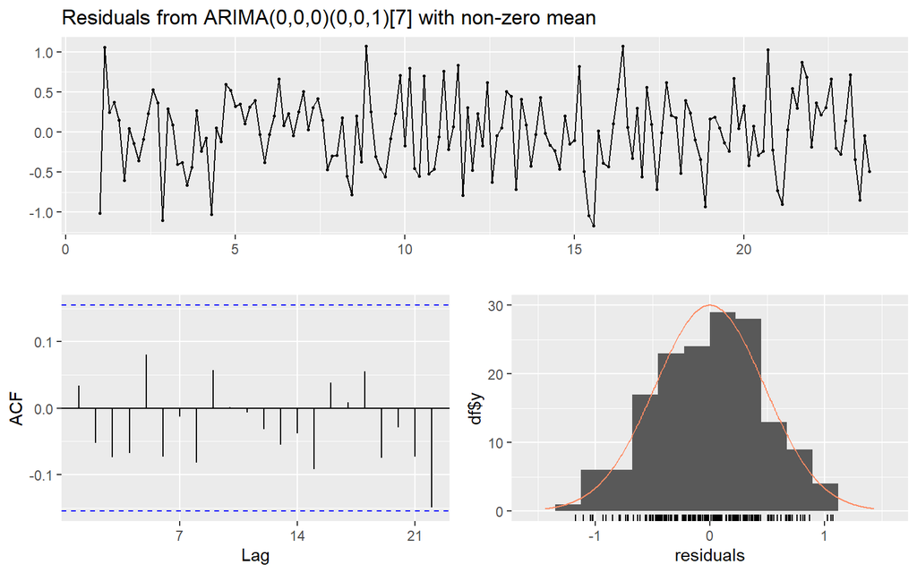

```
##
##  Ljung-Box test
##
## data:  Residuals from ARIMA(0,0,0)(0,0,1)[7] with non-zero mean
## Q* = 7.0201, df = 13, p-value = 0.9011
##
## Model df: 1.   Total lags used: 14
```

```r
# ARIMA musiman
checkresiduals(fit_arima)
```

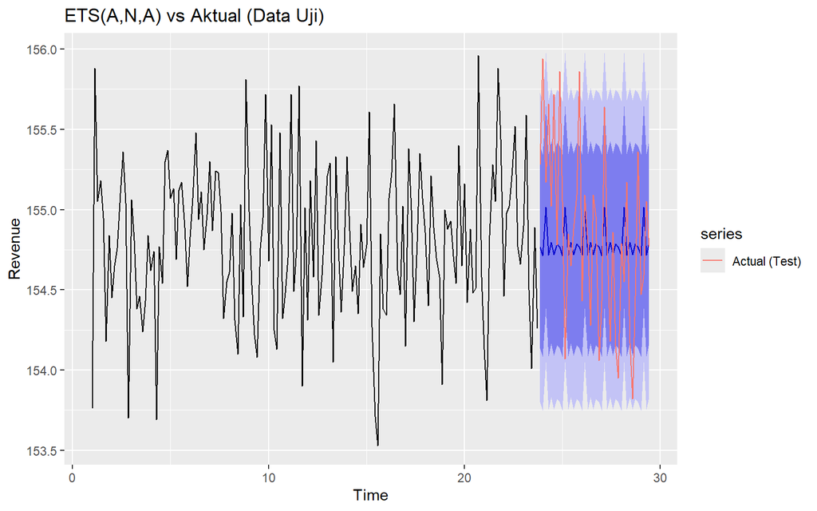

```r
autoplot(fc_ets_ana) + autolayer(y_test, series="Actual (Test)") +
  labs(title="ETS(A,N,A) vs Aktual (Data Uji)", y = "Revenue")
```

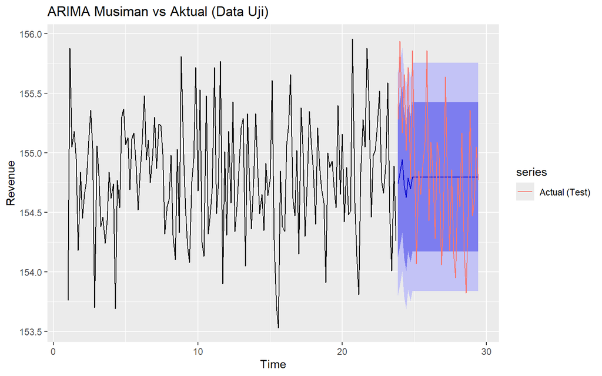

```r
autoplot(fc_arima) + autolayer(y_test, series="Actual (Test)") +
  labs(title="ARIMA Musiman vs Aktual (Data Uji)", y = "Revenue")
```

Hasil **checkresiduals** menunjukkan bahwa kedua kandidat model lolos uji diagnostik: untuk **ETS(A,N,A)** p-value uji Ljung–Box = **0,617**, sedangkan untuk **ARIMA(0,0,0)(0,0,1)[7] dengan mean** p-value = **0,901**. Nilai p-value yang lebih besar dari 0,05 pada kedua model menandakan residu berperilaku seperti **white noise** (tidak menyisakan autokorelasi yang berarti), sehingga keduanya **valid** secara statistik.

# ETS(A,N,A)

## Refit & Ramal

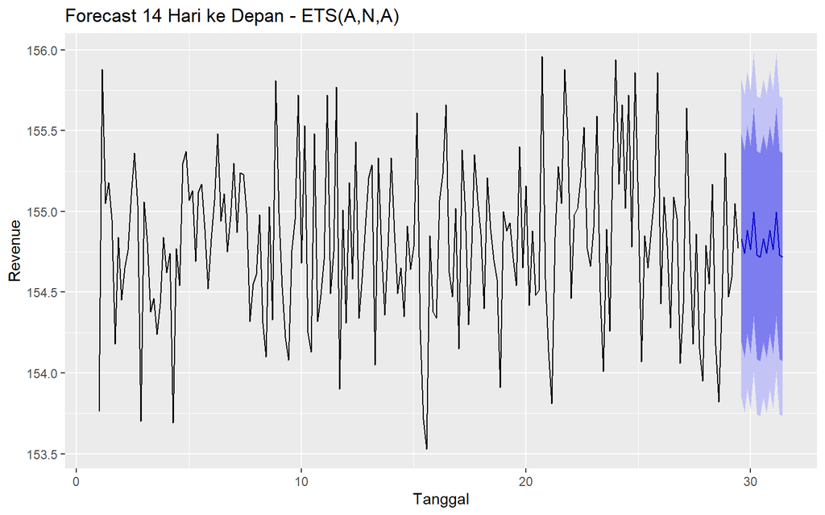

```r
library(forecast)
fit_final <- ets(y, model = "ANA")

h_final <- 14
fc_final <- forecast(fit_final, h = h_final)

autoplot(fc_final) +
  ggplot2::labs(title = paste0("Forecast ", h_final, " Hari ke Depan - ETS(A,N,A)"),
                x = "Tanggal", y = "Revenue")
```

```r
# Tabel hasil (titik ramalan & interval)
as_tibble(fc_final)
```

```
## # A tibble: 14 × 5
##    `Point Forecast` `Lo 80` `Hi 80` `Lo 95` `Hi 95`
##               <dbl>   <dbl>   <dbl>   <dbl>   <dbl>
##  1             155.    154.    155.    154.    156.
##  2             155.    154.    155.    154.    156.
##  3             155.    154.    156.    154.    156.
##  4             155.    154.    155.    154.    156.
##  5             155.    154.    156.    154.    156.
##  6             155.    154.    155.    154.    156.
##  7             155.    154.    155.    154.    156.
##  8             155.    154.    155.    154.    156.
##  9             155.    154.    155.    154.    156.
## 10             155.    154.    156.    154.    156.
## 11             155.    154.    155.    154.    156.
## 12             155.    154.    156.    154.    156.
## 13             155.    154.    155.    154.    156.
## 14             155.    154.    155.    154.    156.
```

```r
# Ringkasan model ETS
summary(fit_final)
```

```
## ETS(A,N,A)
##
## Call:
## ets(y = y, model = "ANA")
##
##   Smoothing parameters:
##     alpha = 1e-04
##     gamma = 1e-04
##
##   Initial states:
##     l = 154.8092
##     s = 0.0758 -0.0701 0.0224 -0.0909 -0.0794 0.1866
##            -0.0444
##
##   sigma:  0.5024
##
##      AIC     AICc      BIC
## 795.1102 796.2742 828.0934
##
## Training set error measures:
##                         ME      RMSE      MAE          MPE      MAPE      MASE
## Training set -0.0009008038 0.4909646 0.391343 -0.001584112 0.2528002 0.7702346
##                    ACF1
## Training set 0.04913906
```

Parameter model **ETS(A,N,A)** menunjukkan bahwa deret berada pada level yang sangat stabil. Nilai **alpha ≈ 0,0001** menandakan pembaruan level berjalan amat pelan sehingga model memperlakukan rata-rata level hampir konstan dari waktu ke waktu. Nilai **gamma ≈ 0,0001** mengindikasikan komponen musiman mingguan juga nyaris tidak berubah antarminggu, pola harian dalam satu minggu relatif tetap. Vektor **indeks musiman 7 hari** seimbang (jumlahnya mendekati nol), yang berarti komponen musiman aditif terestimasi dengan baik dan tidak menggeser level secara sistematis.

Berdasarkan model tersebut, **ramalan 14 hari ke depan** memusat di kisaran **154,73–154,99** (rata-rata sekitar **154,8 USD**). Ketidakpastian yang wajar ditunjukkan oleh **interval prediksi 95%** sekitar **153,73–155,98**. Fan chart mempertahankan gelombang mingguan yang sama seperti pada data historis, konsisten dengan temuan dekomposisi STL dan ACF/PACF bahwa musiman mingguan adalah pola dominan sementara tren jangka pendek tidak signifikan.

# Kesimpulan